# 4: Assigning farm locations

FAO Climate Change Risks to Fed Mariculture

Author

Tormey Reimer

Published

1 April 2026

← Previous: Check species: Atlantic salmon

Next: Home →

# Overview

This document imports data from Clawson et al. (2022) on known and modelled mariculture locations and assigns farms to the species being modelled here. However, there are some challenges to overcome in this process:

- The data from Clawson et al. (2022) is from 2017 and was based on contemporary aquaculture production data, which has increased significantly since then (and possibly changed in relative species production). New aquaculture locations will not be estimated to accomodate for this - instead, each location will likely produce more than is intended. This is because the aim of this study is to examine change in production/feed demand with climate change, not accurately predict current production.
- There are some gaps acknowledged by Clawson et al. (2022), particularly surrounding China’s production locations.
- There is a possibility that any particular country/FAO fishing region will not have enough farms or farms of a specified type to accomodate all of that country’s production. In this case, we will use habitat suitability (temperature range) to place additional farms within that country’s EEZ.

# Get data

**Get mariculture locations data**

```r
aqua_locs <- file.path(prepdata_path, "mariculture_locations_FAO_codes.qs") %>%
    qd_read() %>%
    rename(ISO3_Code = iso3c) %>%
    mutate(across(where(is.character), str_trim))
```

**Make sure the mariculture locations data looks right**

```
ℹ Adding new coordinate system, which will replace the existing one.
```

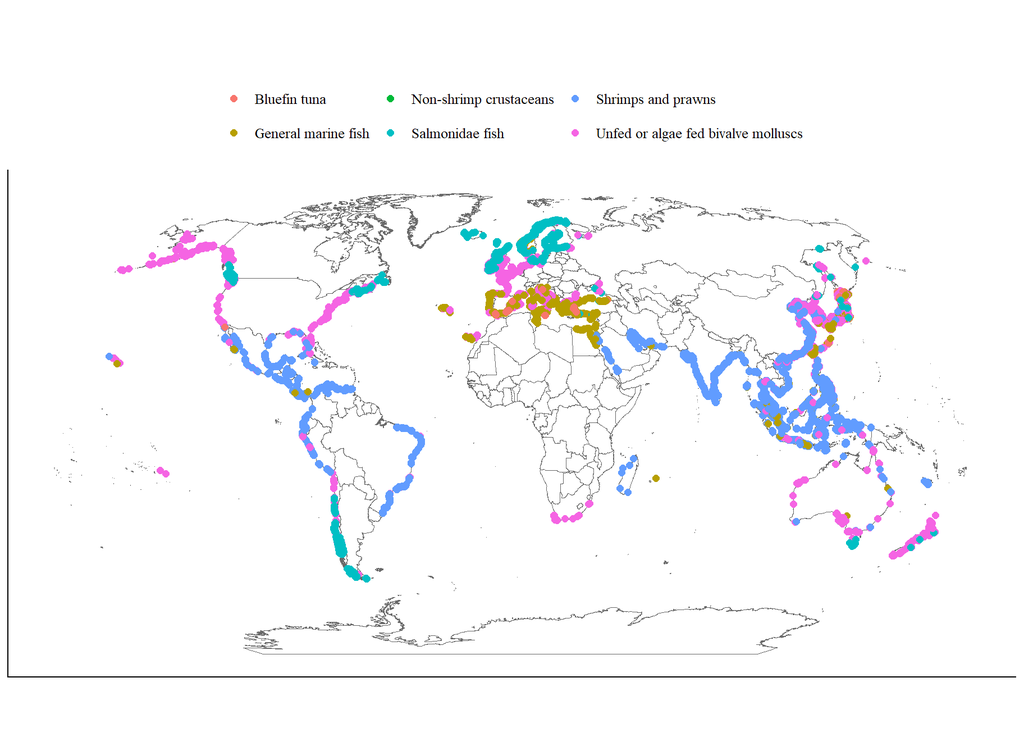

Figure 1: Map of mariculture locations, coloured by species group.

```r
p_bigmap_robinson +
  geom_sf(
    data = aqua_locs %>% st_transform(crs = crs_robin),
    aes(color = species_group, geometry = geometry),
    size = 2
  ) +
  coord_sf() +
  prettyplot() +
  theme(legend.position = "top") +
  rm_x_axis() + rm_y_axis()
```

**Get prepared production data - already filtered by assigned model names**

```r
FAO_aqua <- file.path(prepdata_path, "FAO_with_models_final_production.csv") %>%
    read.csv() %>%
    mutate(across(where(is.character), str_trim))

# Get FAO fishing region code keys and add to production data
FAO_code_key <- file.path(prepdata_path, "FAO_code_key.csv") %>%
    read.csv() %>% select(-X)
FAO_aqua <- FAO_aqua %>%
    left_join(FAO_code_key, by = c("fao_fishing_area" = "NAME_EN"))

# Check that none were left blank
# FAO_aqua %>%
#     filter(is.na(F_CODE)) %>%
#     pull(fao_fishing_area) %>%
#     unique()

# Add groups based on the location data groups
FAO_aqua <- FAO_aqua %>%
    mutate(
        location_group = case_when(
            model_name %in% c("tuna") ~ "Bluefin tuna",
            model_name %in% c("rainbow_trout", "atlantic_salmon") ~ "Salmonidae fish",
            model_name %in% c("whiteleg_shrimp", "tiger_prawn") ~ "Shrimps and prawns",
            model_name %in% c("mud_crab") ~ "Non-shrimp crustaceans",
            model_name %in% c("japanese_sea_cucumber", "abalone") ~ "Unfed or algae fed bivalve molluscs",
            TRUE ~ "General marine fish",
        )
    ) %>%
    select(-c(fao_fishing_area, species_name, environment))

str(FAO_aqua)
```

```
'data.frame':   3005 obs. of  7 variables:
 $ period        : int  2012 2014 2016 2018 2020 2022 2012 2014 2016 2018 ...
 $ value         : num  400 700 800 1000 2875 ...
 $ country       : chr  "Albania" "Albania" "Albania" "Albania" ...
 $ ISO3_Code     : chr  "ALB" "ALB" "ALB" "ALB" ...
 $ model_name    : chr  "european_seabass" "european_seabass" "european_seabass" "european_seabass" ...
 $ F_CODE        : int  37 37 37 37 37 37 37 37 37 37 ...
 $ location_group: chr  "General marine fish" "General marine fish" "General marine fish" "General marine fish" ...
```

Production has increased since 2017 (Figure 2). Since the aquaculture mapping data was based on production data, there will be some additional uncertanties based on this change - however the only real implications will be changes in the ratios of species produced. However, from Figure 2, it looks like the changes aren’t all that drastic.

**Show how production of each mapped group has changed in the last 5 years**

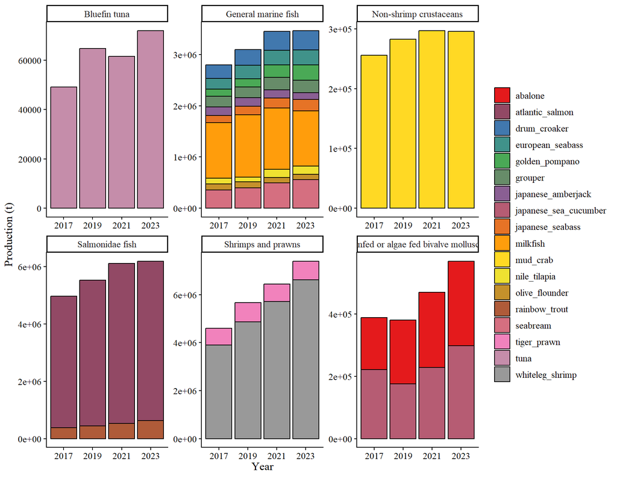

Figure 2: Comparing global production of each `model_name` from 2017 – 2023, split by the groupings present in the aquaculture mapping data.

```r
FAO_aqua %>%
    # I don't know why the years are paired like this in the data but they are - even-numbered years have ~3x the production of odd numbered years
    mutate(period = case_when(
        period %in% 2022:2023 ~ 2023,
        period %in% 2020:2021 ~ 2021,
        period %in% 2018:2019 ~ 2019,
        period %in% 2016:2017 ~ 2017
    )) %>%
    group_by(period, model_name, location_group) %>%
    reframe(total_value = sum(value, na.rm = T)) %>%
    filter(period %in% c(2017:max(FAO_aqua$period))) %>%
    ggplot(aes(
        x = as.factor(period),
        y = total_value,
        fill = model_name
    )) +
    geom_col(colour = "black") +
    facet_wrap(~location_group, scales = "free") +
    scale_fill_manual(
        name = "Model name",
        values = colorRampPalette(brewer.pal(9, "Set1"))(18)
    ) +
    prettyplot() +
    theme(legend.position = "right") +
    labs(
        x = "Year", y = "Production (t)"
    )
```

```r
FAO_aqua_means <- FAO_aqua %>%
    filter(period >= 2017) %>%
    group_by(ISO3_Code, country, F_CODE, location_group, model_name) %>%
    reframe(value = mean(value, na.rm = TRUE)) %>%
    filter(value != 0)

rm(FAO_aqua)
str(FAO_aqua_means)
```

```
tibble [351 × 6] (S3: tbl_df/tbl/data.frame)
 $ ISO3_Code     : chr [1:351] "ALB" "ALB" "ALB" "ARE" ...
 $ country       : chr [1:351] "Albania" "Albania" "Albania" "United Arab Emirates" ...
 $ F_CODE        : int [1:351] 37 37 37 51 51 51 51 51 51 51 ...
 $ location_group: chr [1:351] "Bluefin tuna" "General marine fish" "General marine fish" "General marine fish" ...
 $ model_name    : chr [1:351] "tuna" "european_seabass" "seabream" "european_seabass" ...
 $ value         : num [1:351] 96 2166 3521 523 215 ...
```

# Assign locations

For each country and FAO fishing region combination, we follow these steps:

**Check which countries/FAO codes are present in each dataset.**

```r
# CHECK COUNTRY NAMES!
countries_fix <- left_join(
    FAO_aqua_means %>% distinct(ISO3_Code, country),
    aqua_locs %>% st_drop_geometry() %>% distinct(ISO3_Code, country),
    by = "ISO3_Code"
) %>%
    mutate(country = case_when(
        is.na(country.x) ~ country.y,
        is.na(country.y) ~ country.x,
        T ~ country.y
    )) %>%
    select(ISO3_Code, country)

# Fix country names!
FAO_aqua_means <- FAO_aqua_means %>%
    rows_update(countries_fix, by = c("ISO3_Code"))
locs_crs <- st_crs(aqua_locs)
aqua_locs <- aqua_locs %>%
    mutate(lon = st_coordinates(aqua_locs)[, 1], lat = st_coordinates(aqua_locs)[, 2]) %>%
    st_drop_geometry() %>%
    rows_update(
        filter(countries_fix, ISO3_Code %in% aqua_locs$ISO3_Code),
        by = "ISO3_Code"
    ) %>%
    st_as_sf(coords = c("lon", "lat"), crs = locs_crs)

all_regions_production <- FAO_aqua_means %>%
    distinct(ISO3_Code, country, F_CODE)

all_regions_locations <- aqua_locs %>%
    st_drop_geometry() %>%
    distinct(ISO3_Code, country, F_CODE)

# In production but not locations
in_prod_not_loc <- anti_join(all_regions_production, all_regions_locations, by = c("ISO3_Code", "F_CODE"))

# In locations but not production
in_loc_not_prod <- anti_join(all_regions_locations, all_regions_production, by = c("ISO3_Code", "F_CODE"))

cat(sprintf(
    "In production data but not locations: %d\nIn locations but not production data: %d\n",
    nrow(in_prod_not_loc), nrow(in_loc_not_prod)
))
```

```
In production data but not locations: 46
In locations but not production data: 17
```

Any farmed locations that don’t correspond with any production data will be excluded (they’re likely species not included in the `model_names` chosen). Any production values not included in the farmed locations will be included - farmed locations will be generated for them later.

**Put groups in order of most specific -> most general**

```r
# Location groups are handled in order, from most specific -> most general (in terms of the number of model names assigned to them)
groups_order <- c(
    "Bluefin tuna",
    "Non-shrimp crustaceans",
    "Salmonidae fish",
    "Shrimps and prawns",
    "Unfed or algae fed bivalve molluscs",
    "General marine fish"
)
```

```r
# this_group <- groups_order[1]

set.seed(5678)
group_locations <- map_dfr(
    groups_order,
    function(this_group) {
        all_regions_production <- FAO_aqua_means %>%
            filter(location_group == this_group) %>%
            group_by(ISO3_Code, F_CODE) %>%
            mutate(prop_regional_value = sum(value, na.rm = T)) %>%
            ungroup() %>%
            mutate(prop_regional_value = value/prop_regional_value) %>%
            group_by(ISO3_Code, F_CODE) %>%
            group_split()

        all_region_locs <- aqua_locs %>%
            filter(species_group == this_group) %>%
            rename(t_per_farm_2017 = tonnes_per_farm) %>%
            st_drop_geometry() %>%
            select(-NAME_EN)

        # this_region_prod <- all_regions_production[[1]]
        map_dfr(
            all_regions_production,
            function(this_region_prod) {
                this_region_locs <- all_region_locs %>%
                    filter(ISO3_Code == unique(this_region_prod$ISO3_Code) & F_CODE == unique(this_region_prod$F_CODE)) %>%
                    group_by(species_group) %>%
                    mutate(prop_species_tonnes = sum(t_per_farm_2017, na.rm = T)) %>%
                    ungroup() %>%
                    mutate(prop_species_tonnes = t_per_farm_2017/prop_species_tonnes)

                # Is there any production to be assigned?
                any_production <- (nrow(this_region_prod) != 0)
                # Are there any locations to be assigned?
                any_locations  <- (nrow(this_region_locs) != 0)
                # Are there enough farms to assign at least one per model_name?
                enough_farms   <- (nrow(this_region_locs) >= nrow(this_region_prod))

                if (any_production & any_locations & enough_farms) {
                    # If there are enough farms, split them by proportion of salmonidae production for each model (down-regulating if production decreases from 2017 to 2023)

                    # First decide how to partition all available farms
                    all_farms <- unique(this_region_locs$farm_ID)
                    this_region_prod_mod <- this_region_prod %>%
                        mutate(
                            n_farms_raw     = prop_regional_value * length(all_farms),
                            n_farms         = pmax(floor(n_farms_raw), 1L),
                            remainder       = n_farms_raw - floor(n_farms_raw)
                        )
                    # Distribute leftover farms to rows with largest remainders (avoids rounding errors)
                    leftover <- length(all_farms) - sum(this_region_prod_mod$n_farms)
                    this_region_prod_mod <- this_region_prod_mod %>%
                        mutate(n_farms = n_farms + (rank(-remainder, ties.method = "first") <= leftover),) %>%
                        select(-n_farms_raw, -remainder)

                    # Based on all available farms being assigned, does the per-farm production increase from 2017 to 2023 (expected behaviour)? If not, reduce the number of assigned farms
                    this_region_prod_mod <- this_region_prod_mod %>%
                        mutate(
                            t_per_farm_2017 = mean(this_region_locs$t_per_farm_2017),
                            t_per_farm_2023 = value/n_farms,
                            increase_ratio  = t_per_farm_2023/t_per_farm_2017,
                            n_farms         = pmax(1, pmin(n_farms, floor(n_farms * increase_ratio)))
                        ) %>%
                        select(-increase_ratio)

                    # Sample the required number of farms (may be all) and assign to all model names at once with no overlaps
                    samp_farms <- sample(all_farms, sum(this_region_prod_mod$n_farms), replace = F)
                    assigned_farms <- map2(
                        this_region_prod_mod$model_name,
                        split(samp_farms, rep(this_region_prod_mod$model_name, this_region_prod_mod$n_farms)),
                        ~ data.frame(model_name = .x, farm_ID = .y)
                        ) %>%
                        list_rbind() %>%
                        left_join(this_region_locs, by = join_by(farm_ID))

                    production_locations <- this_region_prod %>%
                        left_join(
                            assigned_farms,
                            by = c("ISO3_Code", "country", "F_CODE", "location_group" = "species_group", "model_name")
                        )
                    } else if (any_production & any_locations & !enough_farms) {
                        # If there aren't enough farms to split between the two productions, assign to the larger ones first
                        production_locations <- this_region_prod %>%
                            arrange(desc(value)) %>%
                            mutate(.row = row_number()) %>%
                            left_join(
                                this_region_locs %>% mutate(.row = row_number()),
                                by = c(".row", "ISO3_Code", "country", "F_CODE", "location_group" = "species_group")
                            ) %>%
                            select(-.row) %>%
                            mutate(t_per_farm_2023 = prop_species_tonnes * value)
                    } else if (any_production & !any_locations) {
                        # If there aren't any locations the assignments are left blank
                        production_locations <- this_region_prod %>%
                            mutate(t_per_farm_2017 = NA, farm_ID = NA, prop_species_tonnes  = NA, t_per_farm_2023 = NA)
                    } else {
                        print("There's no production... you shouldn't be here")
                    }
                return(production_locations)
            }
        ) %>%
            select(-prop_species_tonnes, -prop_regional_value, -t_per_farm_2023)
    },
    .progress = T
)

qd_save(group_locations, file.path(data_path, "intermediates", "group_locations_first_assignment.qs"))
```

```r
options(width = 120)

group_locations <- file.path(data_path, "intermediates", "group_locations_first_assignment.qs") %>%
  qd_read()

farms_assigned <- unique(group_locations$farm_ID[!is.na(group_locations$farm_ID)])
farms_unassigned <- setdiff(unique(aqua_locs$farm_ID), farms_assigned)

# These countries were assigned production - I want to check how many farms were assigned and how much the estimated tonnage has changed from the location to production process. A small increase in production is fine, but a decrease indicates that too many farms were assigned (it's too spread out)
assigned_group_summary <- group_locations %>%
    filter(!is.na(farm_ID)) %>%
    group_by(country, F_CODE, model_name, value) %>%
    reframe(
        number_of_farms = n(),
        t_per_farm_2017 = mean(t_per_farm_2017, na.rm = T)
    ) %>%
    mutate(
        t_per_farm_2023 = value/number_of_farms,
        increase_ratio = t_per_farm_2023/t_per_farm_2017
    ) %>%
    filter(number_of_farms > 1) %>%
    arrange(increase_ratio)
```

**Map assigned farm locations by model name**

```
ℹ Adding new coordinate system, which will replace the existing one.
```

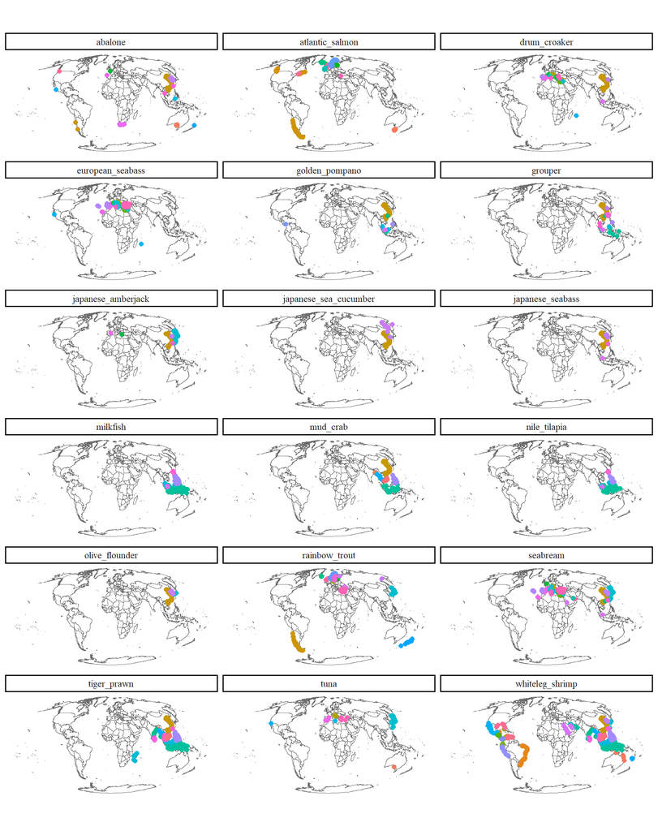

Figure 3: Map of assigned farm locations for each model name, coloured by country.

```r
group_locations_geom <- group_locations %>%
  distinct(model_name, farm_ID) %>%
  left_join(
    aqua_locs %>% st_transform(crs = "+proj=moll"),
    by = join_by(farm_ID)
  ) %>%
  filter(!is.na(farm_ID))

p_bigmap_mollweide +
  geom_sf(
    data = group_locations_geom,
    aes(geometry = geometry, colour = country),
    size = 2
  ) +
  coord_sf() +
  facet_wrap(~model_name, ncol = 3) +
  prettyplot() +
  rm_y_axis() + rm_x_axis()
```

**Show regions/models that have production values but no locations assigned**

```r
group_locations %>%
    filter(is.na(farm_ID)) %>%
    group_by(model_name) %>%
    reframe(
        regions = n(),
        value = sum(value)
    ) %>%
    left_join(
        FAO_aqua_means %>%
            group_by(model_name) %>%
            reframe(
                total_regions = n(),
                total_value = sum(value)
            )
    ) %>%
    mutate(
        prop_regions = 100*regions/total_regions,
        prop_value = 100*value/total_value
    ) %>%
    arrange(-prop_value) %>%
    gt() %>%
    fmt_number(
      columns = c(prop_regions, prop_value, value, total_value),
      decimals = 2
    )
```

Table 1: Summary of model names with production records that could not be assigned to any mapped farm location, showing number of unassigned regions and proportion of total production value.

| model_name | regions | value | total_regions | total_value | prop_regions | prop_value |
| --- | --- | --- | --- | --- | --- | --- |
| mud_crab | 20 | 11,025.81 | 26 | 275,711.30 | 76.92 | 4.00 |
| tuna | 3 | 1,585.67 | 11 | 65,042.27 | 27.27 | 2.44 |
| drum_croaker | 11 | 2,601.75 | 27 | 181,897.29 | 40.74 | 1.43 |
| nile_tilapia | 10 | 812.66 | 16 | 70,136.35 | 62.50 | 1.16 |
| seabream | 12 | 3,620.42 | 37 | 320,051.57 | 32.43 | 1.13 |
| european_seabass | 12 | 2,136.17 | 29 | 235,391.98 | 41.38 | 0.91 |
| japanese_amberjack | 3 | 1,214.00 | 9 | 156,535.01 | 33.33 | 0.78 |
| atlantic_salmon | 4 | 18,084.11 | 16 | 2,617,900.03 | 25.00 | 0.69 |
| grouper | 7 | 572.93 | 18 | 205,522.94 | 38.89 | 0.28 |
| whiteleg_shrimp | 30 | 5,970.82 | 67 | 2,705,164.33 | 44.78 | 0.22 |
| rainbow_trout | 5 | 398.49 | 18 | 369,053.82 | 27.78 | 0.11 |
| milkfish | 13 | 263.47 | 19 | 600,905.44 | 68.42 | 0.04 |
| tiger_prawn | 7 | 247.10 | 22 | 748,553.48 | 31.82 | 0.03 |
| golden_pompano | 1 | 42.35 | 9 | 210,542.16 | 11.11 | 0.02 |
| olive_flounder | 1 | 9.50 | 4 | 61,171.10 | 25.00 | 0.02 |
| abalone | 2 | 4.67 | 15 | 222,466.72 | 13.33 | 0.00 |

## References

← Previous: Check species: Atlantic salmon

Next: Home →

## References

Clawson, Gage, Caitlin D. Kuempel, Melanie Frazier, Gordon Blasco, Richard S. Cottrell, Halley E. Froehlich, Marc Metian, et al. 2022. ‘Mapping the Spatial Distribution of Global Mariculture Production’. *Aquaculture* 553 (May): 738066. https://doi.org/10.1016/j.aquaculture.2022.738066.